# Unsafe Schools: The Global Water & Sanitation Crisis

A UNICEF Data Story on Children’s Right to Clean Water in Schools

Author

Sreeja Ajith

Published

April 13, 2026

## The Crisis Hiding in Plain Sight

Every morning, **millions of children walk into schools that lack basic clean water**. They study, play, and grow in environments where handwashing is impossible, toilets are unusable, and dehydration is a daily reality. This is not a distant problem – it is happening **right now, in over 140 countries** tracked by UNICEF.

## Indicators Used

This report focuses on two key UNICEF indicators:

- **Schools with limited drinking water services (%)** – representing the proportion of schools where children lack reliable access to safe drinking water.
- **Population with inadequate sanitation (%)** – capturing broader environmental conditions that affect children’s health both inside and outside school.

Together, these indicators provide a comprehensive view of the **water and sanitation challenges affecting children globally**.

> *“Water and sanitation are not luxuries. They are human rights – and for children, they are the foundation of health, dignity, and education.”* – UNICEF

## Data Transformation

To ensure accurate and meaningful analysis:

- Only **Total population values** were used to avoid gender-based duplication or bias
- Country-level averages were calculated to summarise long-term trends across years
- Missing values were removed to improve data reliability
- External socioeconomic data (GDP, population, life expectancy) were merged to explore relationships between **economic development and school conditions**

## Where Are Schools Failing Children Most?

The map below shows the **average proportion of schools with limited drinking water access** across all available years. Darker shades indicate a higher percentage of schools where children lack adequate water.

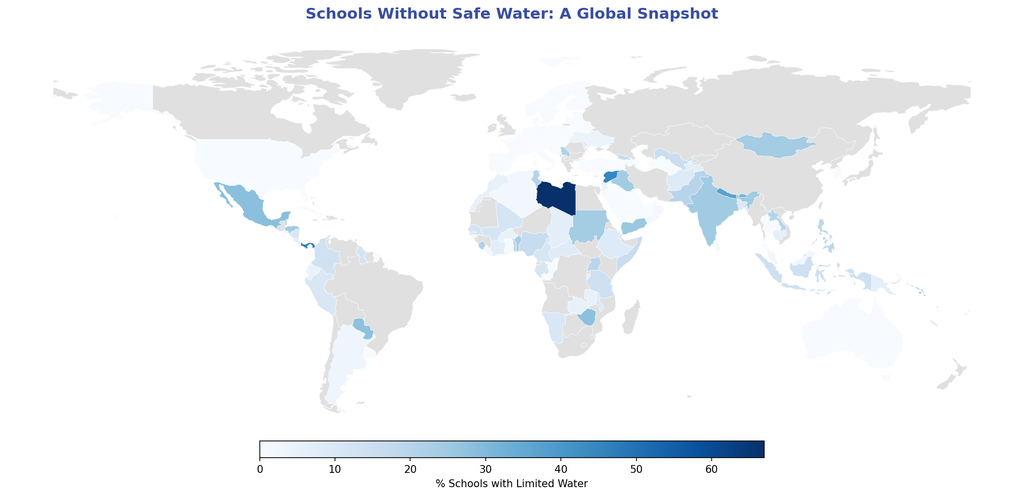

Figure 1: Average % of schools with limited drinking water services by country.

```python
fig, ax = plt.subplots(1, 1, figsize=(14, 7))
world_map_df.plot(ax=ax, color="#e0e0e0", edgecolor="white", linewidth=0.3)
has_data = world_map_df.dropna(subset=["pct_limited_water"])
has_data.plot(
    column="pct_limited_water", ax=ax, cmap="Blues",
    edgecolor="white", linewidth=0.3, legend=True,
    legend_kwds={"label": "% Schools with Limited Water",
                 "orientation": "horizontal", "shrink": 0.5,
                 "pad": 0.02, "aspect": 30}
)
ax.set_title("Schools Without Safe Water: A Global Snapshot",
             fontsize=15, fontweight="bold", color=UNICEF_DARK, pad=12)
ax.axis("off")
plt.tight_layout()
plt.savefig("chart_map.png", dpi=150, bbox_inches="tight")
plt.close()
display(IPImage("chart_map.png"))
```

## The 15 Worst-Affected Countries

The bar chart below ranks the **15 countries with the highest average proportion of schools lacking adequate drinking water**.

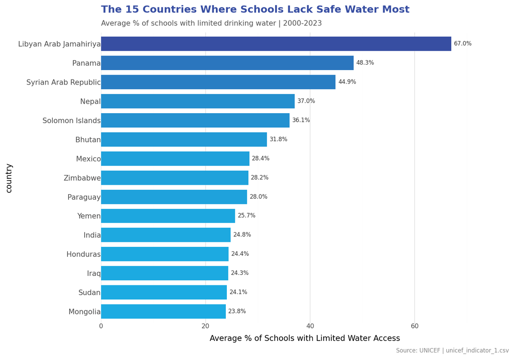

Figure 2: Top 15 countries by average % of schools with limited drinking water (2000-2023).

```python
p1 = (
    ggplot(top15, aes(x="country", y="pct_limited_water", fill="pct_limited_water"))
    + geom_col(width=0.75, show_legend=False)
    + geom_text(aes(label="pct_limited_water"),
                format_string="{:.1f}%", ha="left", size=8,
                nudge_y=0.5, color="#333333")
    + scale_fill_gradient(low=UNICEF_BLUE, high=UNICEF_DARK)
    + scale_y_continuous(expand=(0, 0), limits=(0, 78))
    + coord_flip()
    + labs(title="The 15 Countries Where Schools Lack Safe Water Most",
           subtitle="Average % of schools with limited drinking water | 2000-2023",
           x=None, y="Average % of Schools with Limited Water Access",
           caption="Source: UNICEF | unicef_indicator_1.csv")
    + theme_minimal()
    + theme(plot_title=element_text(size=14, face="bold", color=UNICEF_DARK),
            plot_subtitle=element_text(size=10, color="#555555"),
            plot_caption=element_text(size=8, color="#888888"),
            axis_text_y=element_text(size=10),
            axis_text_x=element_text(size=9),
            panel_grid_major_y=element_blank(),
            figure_size=(10, 7))
)
p1.save("chart_bar.png", dpi=150, verbose=False)
display(IPImage("chart_bar.png"))
```

**What the data tells us:**

- **Libya** stands out with a staggering **67%** average – meaning two thirds of schools have limited water access.
- **Panama, Syria, Nepal,** and **Solomon Islands** all exceed 35%, reflecting both conflict and geographic isolation as key drivers.
- The presence of **middle-income countries** like Mexico and India underlines that the crisis is also a **governance and infrastructure failure**.

## Wealth vs. Water: Is GDP the Answer?

If clean water in schools were simply a matter of money, we would expect a perfect negative relationship between GDP per capita and school water deprivation. The scatterplot below tests this assumption.

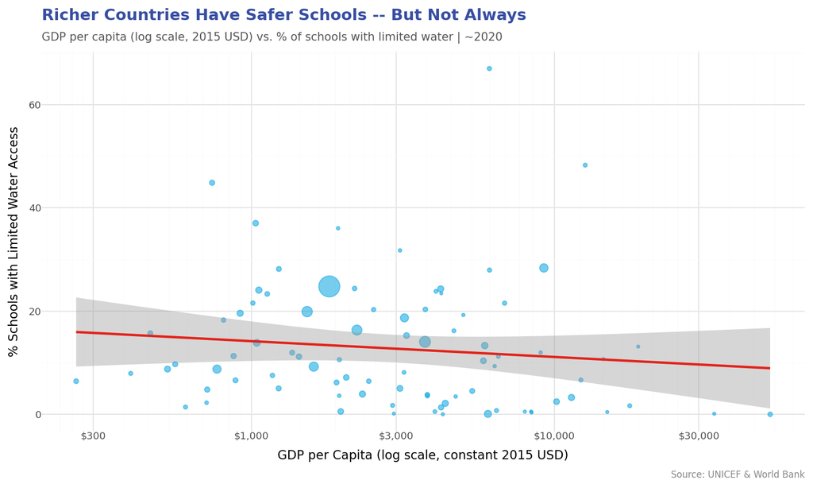

Figure 3: Each point is one country. The regression line shows the trend between national wealth and school water deprivation.

```python
p2 = (
    ggplot(scatter_df, aes(x="gdp", y="pct_limited_water", size="population"))
    + geom_point(color=UNICEF_BLUE, alpha=0.6, show_legend=False)
    + geom_smooth(method="lm", color=UNICEF_RED, se=True, size=1.2)
    + scale_x_log10(labels=lambda l: [f"${x:,.0f}" for x in l])
    + scale_size_continuous(range=(1, 10), guide=None)
    + labs(title="Richer Countries Have Safer Schools -- But Not Always",
           subtitle="GDP per capita (log scale, 2015 USD) vs. % of schools with limited water | ~2020",
           x="GDP per Capita (log scale, constant 2015 USD)",
           y="% Schools with Limited Water Access",
           caption="Source: UNICEF & World Bank")
    + theme_minimal()
    + theme(plot_title=element_text(size=14, face="bold", color=UNICEF_DARK),
            plot_subtitle=element_text(size=10, color="#555555"),
            plot_caption=element_text(size=8, color="#888888"),
            figure_size=(10, 6))
)
p2.save("chart_scatter.png", dpi=150, verbose=False)
display(IPImage("chart_scatter.png"))
```

**Interpreting the trend:**

- The **negative regression line** confirms that wealthier nations generally have better water access in schools – but the relationship is **not perfect**.
- Several countries with **moderate GDPs** still show high deprivation rates, indicating that **political will, conflict, and institutional capacity** matter as much as raw wealth.

## Are Things Getting Better? A Time-Series View

Progress is possible – but is it happening fast enough? The chart below tracks changes over time for the **5 most-affected countries**.

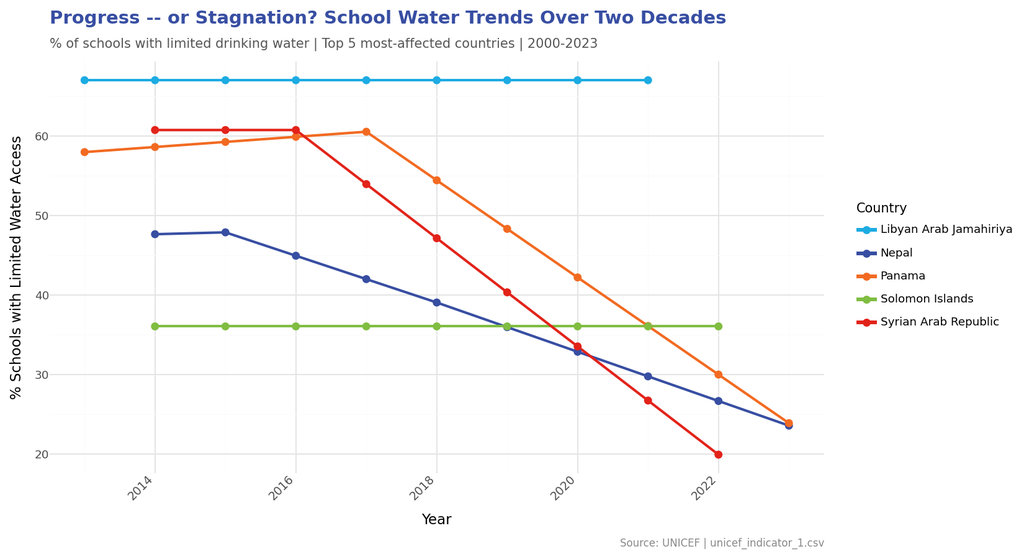

```python
p3 = (
    ggplot(ts_df, aes(x="time_period", y="obs_value", color="country", group="country"))
    + geom_line(size=1.1)
    + geom_point(size=2.5)
    + scale_color_manual(
        values=[UNICEF_BLUE, UNICEF_DARK, UNICEF_ORANGE, UNICEF_GREEN, UNICEF_RED],
        name="Country")
    + scale_x_continuous(breaks=range(2000, 2024, 2))
    + labs(title="Progress -- or Stagnation? School Water Trends Over Two Decades",
           subtitle="% of schools with limited drinking water | Top 5 most-affected countries | 2000-2023",
           x="Year", y="% Schools with Limited Water Access",
           caption="Source: UNICEF | unicef_indicator_1.csv")
    + theme_minimal()
    + theme(plot_title=element_text(size=14, face="bold", color=UNICEF_DARK),
            plot_subtitle=element_text(size=10, color="#555555"),
            plot_caption=element_text(size=8, color="#888888"),
            axis_text_x=element_text(angle=45, ha="right", size=9),
            legend_title=element_text(size=10),
            figure_size=(11, 6))
)
p3.save("chart_timeseries.png", dpi=150, verbose=False)
display(IPImage("chart_timeseries.png"))
```

## What Must Change

The data is clear. The water and sanitation crisis in schools is **not random** – it follows patterns of poverty, conflict, and governance failure. But it is also **not inevitable**.

UNICEF calls for urgent action on three fronts:

1. **Targeted investment** – Governments and donors must prioritise school WASH funding in the 15 highest-burden countries identified in this report.
2. **Conflict-sensitive programming** – Countries like Syria demonstrate that water infrastructure must be protected and rapidly restored in conflict and post-conflict settings.
3. **Accountability mechanisms** – Annual school-level reporting on water and sanitation access must become standard.

> *Every child deserves to learn in a school where they can wash their hands, drink clean water, and use a safe toilet. Until that is true everywhere, the work is not done.*

*Report prepared using UNICEF global indicator data. Visualisations created with plotnine in Python, rendered via Quarto.*